# kongerækken, homework

simone kallehauge

2022-11-28

#indlæs libraries

```r
library(tidyverse)
library(here)
```

#indlæs data

```r
kongeraekken <- read_csv2("../DM03/data/kongerække_homework_csv2.csv")
```

```
## ℹ Using "','" as decimal and "'.'" as grouping mark. Use `read_delim()` for more control.
```

#data visualisering my how-to: i’ve first selected the name and the duration of the reign from my Excel spreadsheet, but in order to to make sure that RStudio order them by reign and not first-name-letter, i make a new column in the spreedsheet, that states what order in the reign they are. here: name_count

next i mutate my data, because R sees the “duration of reign” as a character, not as a number, which then makes my visulization wrong. So in order to make sure it order after the numeric system, i use the function: as.numeric

i then in ggplot reorder my data by name and name_count, (see select)

in order to make the monarchs name readable, i use the function: theme(axis.text.x = element_text(angle=90)) <– this makes it stand verticle

lastly i organize the y-axis by using the “scale_y_continuous(breaks = seq), which makes me able to use lesser numbers (0 = the smallest possible number) (65 = the highest possible number) (5= the breaks: 0,5,10,15,20 etc.)

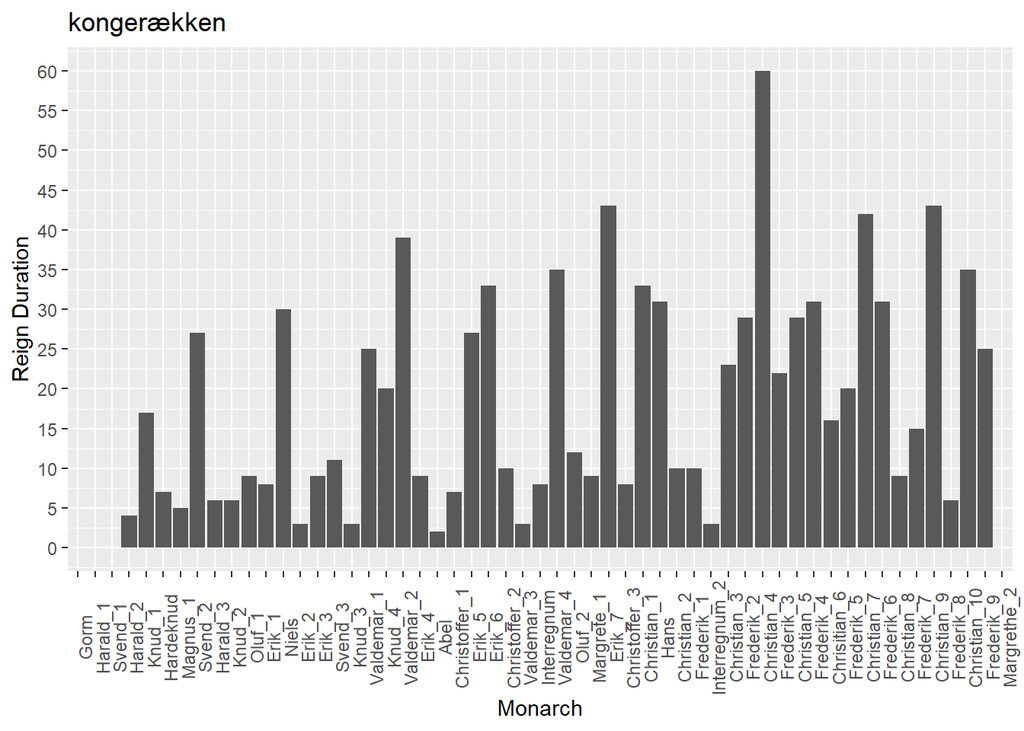

```r
kongeraekken %>%
  select(name, Duration_Of_Reign,name_count) %>%
  mutate(Duration_Of_Reign= as.numeric(Duration_Of_Reign)) %>%
  ggplot(aes(x= reorder(name, name_count), y=Duration_Of_Reign))+
  geom_col()+
  theme(axis.text.x = element_text(angle=90))+
  labs(title = "kongerækken",
       y = "Reign Duration",
       x = "Monarch")+
  scale_y_continuous(breaks = seq(0, 65, 5))
```